# 15. Reinforcment learning

Michał Maj

2021-06-05

# 1 Reinforcment learning

**Uczenie ze wzmocnieniem** (Reinforcment learning) to to obszar uczenia maszynowego dotyczący tego, jak **inteligentni agenci** powinni podejmować działania w **środowisku**, aby zmaksymalizować pojęcie **skumulowanej nagrody**. Uczenie ze wzmocnieniem jest jednym z trzech podstawowych paradygmatów uczenia maszynowego, obok uczenia nadzorowanego i uczenia nienadzorowanego.

Uczenie ze wzmacnianiem różni się od uczenia nadzorowanego brakiem konieczności przedstawiania oznaczonych par wejścia/wyjścia oraz brakiem konieczności wyraźnej korekty działań suboptymalnych. Zamiast tego skupiamy się na znalezieniu równowagi między **eksploracją** (niezbadanego terytorium) a **eksploatacją** (obecnej wiedzy).

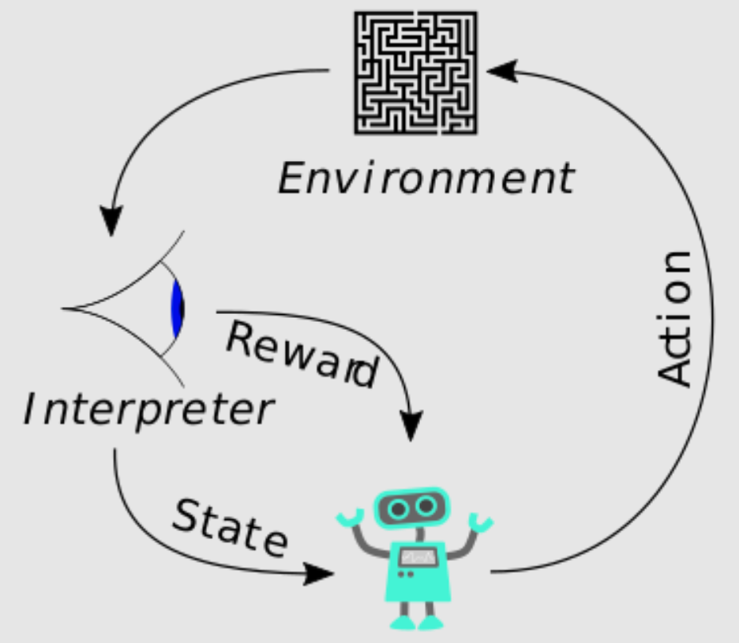

Środowisko zazwyczaj definiowane jest jako **Proces Decyzyjny Markova** (Markov decision process), który jest rozszerzeniem klasycznego **Łańcucha Markova** o mozliwość wyboru akcji oraz otrzymaniu nagrody/kary za tę akcję.

Bardziej formalnie. Obiekt $(S,A,P_a,R_a)$ nazywamy procesem decyzyjnym Markova, gdzie:

- $S$ jest zbiorem wyszystkich stanów naszego procesu
- $A$ jest zbiorem wszystkich akcji naszego procesu ($A_s$ będzie zbiorem akcji dozwolonych dla stanu $s$)
- $P_a(s,s') = P(s_{t+1} = s'| s_t=s, a_t=a)$ jest prawdopodobieństwem tego, że akcja $a$ w stanie $s$ w czasie $t$ doprowadzi do stanu $s'$ w czasie $t+1$.
- $R_a(s,s')$ jest natychmiastową nagrodą (lub oczekiwaną natychmiastową nagrodą) otrzymana po przejsciu ze stanu $s$ to $s'$ poprzez akcję $a$.

Do rozwiązania problemów uczenia ze wzmocnieniem bardzo często używa się **programowania dynamicznego**. Celem uczenia ze wzmocnieniem jest nauczenie agenta optymalnej (bądź prawie optymalnej) taktyki tak, aby zmaksymalizować **funkcję nagrody**.

Jeśli zakładamy, że agent jest w stanie zobaczyć wszystkie stany środowiska problem może zostać zdefiniowany jako klasyczny Proces Decyzyjny Markova, jeśli z jakiegoś powodu agent może zobaczyć tylko część stanów to preblem musi być zdefiniowany jako **Częściowo obserwowalny Proces Decyzyjny Markova**.

## 1.1 Q-learning

**Q-learning** jest algorytmem pozwalającym na znalezienie optymalnej taktyki (dla skończonych Procesów Decyzyjnych Markova) pod względem maksymalizacji oczekiwanej funkcji nagrody (dla kolejnych kroków począwszy od obecnego kroku $s$).

Litera **Q** oznacza jakość (quality). Algorytm kalkuluje wartości Q dla par stan-akcja i na ich podstawie podejmuje kolejne działania (akcje).